# Activity: Graph Replication

Matthew Beckman

```r
# libraries
library(tidyverse)
library(DataComputing)
```

```r
library(mosaicData)
```

# Grading

Assignment is worth a total of 10 points:

- [3 points] Problem 5.3 graph replication
- [3 points] Problem 5.4 graph replication
- Exploration of `diamonds` data
  - [1 point] `ggplot2` expression that successfully produces a graphical display of the `diamonds` data.
  - [1 point] graphic must display at least 3 variables from the `diamonds` data.
  - [2 points] written narrative describing something learned/observed about the `diamonds` data using your graphic.

# Activity

Reproduce plots for Problem 5.3 & Problem 5.4 in the Data Computing Text.

### Problem 5.3

The “yes” and “no” in the gray bars refer to whether or not the person is pregnant.

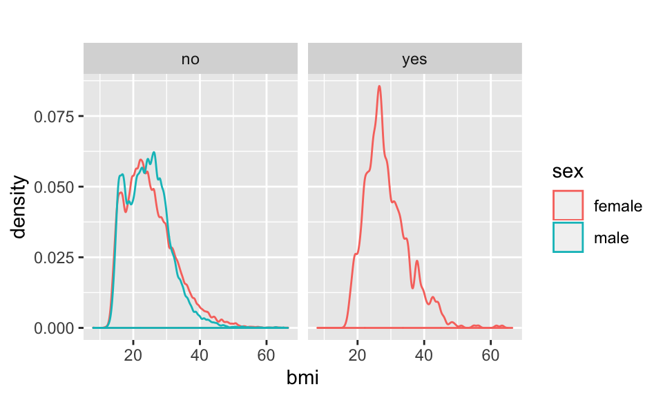

```r
# Note: I've added some spacing to make it a little easier to read the function
 ggplot(data = NCHS, aes(x = bmi)) +
  geom_density(adjust = 0.4) +
  aes(colour = sex) +
  facet_wrap( ~ pregnant, ncol = 4) +
  labs(title = "") +
  theme(legend.position = "right")
```

### Problem 5.4

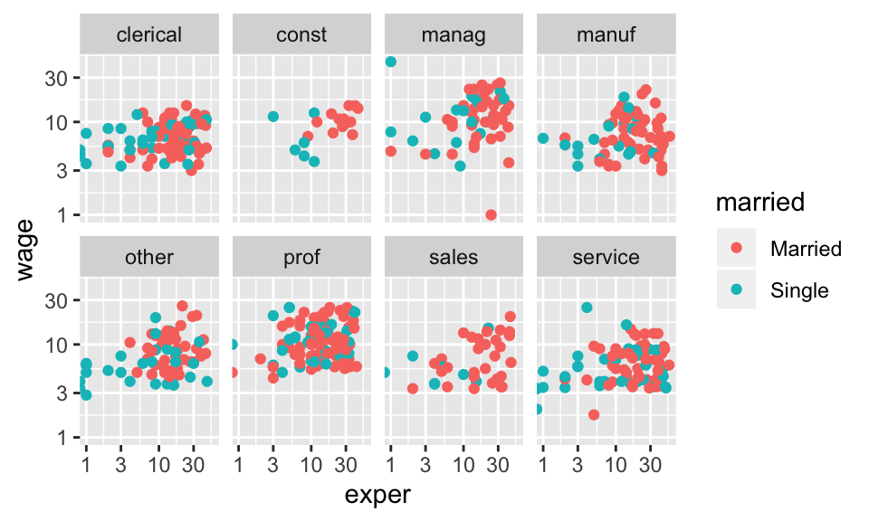

```r
# Note: I've added some spacing to make it a little easier to read the function
ggplot(data = CPS85, aes(x = exper, y = wage)) +
  geom_point() +
  aes(colour = married) +
  scale_x_log10() +
  scale_y_log10() +
  facet_wrap( ~ sector, ncol = 4)
```

### Your Turn: explore the `diamonds` data

*Task: Produce an interesting graphic of the `diamonds` data set. The graphic should represent AT LEAST 3 variables. Write a few sentences to describe what you have learned.*

```r
data("diamonds")
```

### Optional Extension: programming style

The helper functions are great, but they produce ugly code. Clean up the `ggplot2` code that reproduces the required plots so that it aligns with the R Programming Style Guide Appendix in the *DataComputing* eBook https://dtkaplan.github.io/DataComputingEbook/.